# Презентация по выполнению индивидуального проекта №5

Основы информационной безопасности

Осман АлиНиколай

1032239330@rudn.ru

Российский университет дружбы народов

2026-05-16

# Информация

## Докладчик

Осман АлиНиколай

студент

Российского университета дружбы народов им. П. Лумумбы

1032239330@rudn.ru

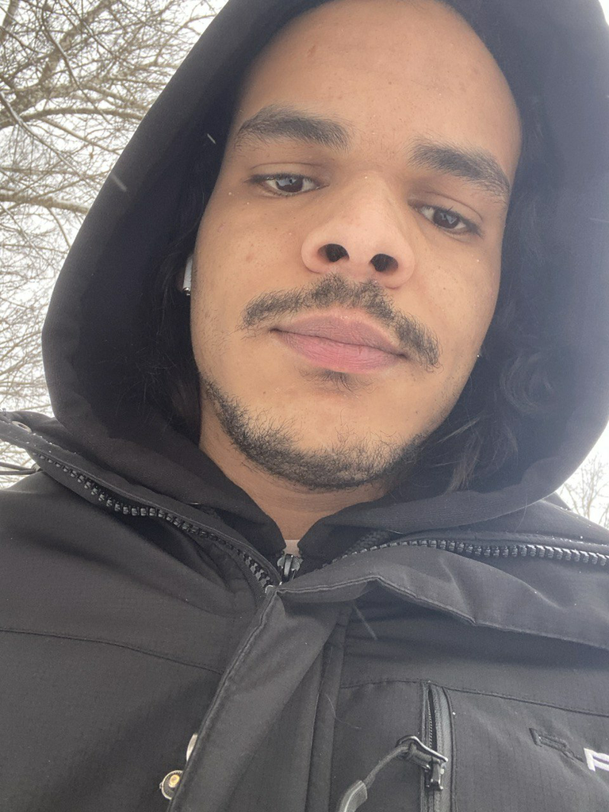

## Цель

Научиться использовать Burp Suite.

## Выполнение лабораторной работы

Запускаю локальный сервер, на котором открою веб-приложение DVWA для тестирования инструмента Burp Suite

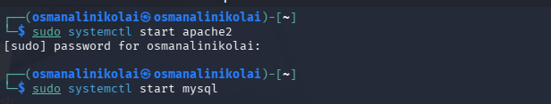

Запуск локального сервера

## Выполнение лабораторной работы

Запускаю инструмент Burp Suite

[figure not shown]

Запуск приложения

## Выполнение лабораторной работы

Открываю сетевые настройки браузера, для подготовке к работе

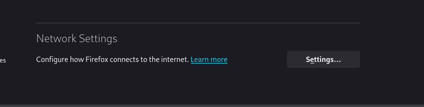

Сетевые настройки браузера

## Выполнение лабораторной работы

Изменение настроек сервера для работы с proxy и захватом данных с помощью Burp Suite

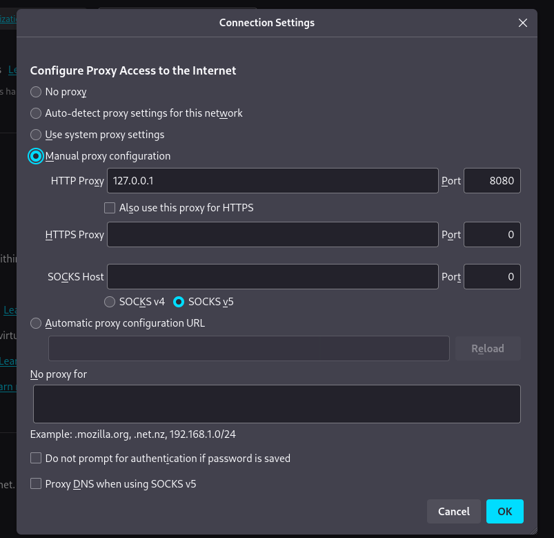

Настройки сервера

## Выполнение лабораторной работы

Изменяю настройки Proxy инструмента Burp Suite для дальнейшей работы

[figure not shown]

Настройки Burp Suite

## Выполнение лабораторной работы

Во вкладке Proxy устанавливаю “Intercept is on”

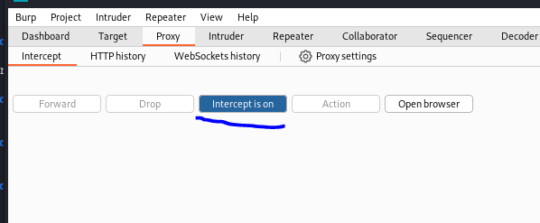

Настройки Proxy

## Выполнение лабораторной работы

Чтобы Burp Suite исправно работал с локальным сервером, наобходимо установить параметр `network_allow_hijacking_loacalhost` на `true`

[figure not shown]

Настройки параметров

## Выполнение лабораторной работы

Пытаюсь зайти в браузере на DVWA, тут же во вкладки Proxy появляется захваченный запрос. Нажимаем “Forward”, чтобы загрузить страницу

[figure not shown]

Получаемые запросы сервера

## Выполнение лабораторной работы

Загрузилась страница авторизации, текст запроса поменялся

[figure not shown]

Страница авторизации

## Выполнение лабораторной работы

История запросов хранится во вкладке Target

[figure not shown]

История запросов

## Выполнение лабораторной работы

Попробуем ввести неправильные, случайные данные в веб-приложении и нажмем `Login`. В запросе увидим строку, в которой отображаются введенные нами данные, то есть поле для ввода

[figure not shown]

Ввод случайных данных

## Выполнение лабораторной работы

Этот запрос так же можно найти во вкладке Target, там же жмем правой кнопкой мыши на хост нужного запроса, и далее нажимаем “Send to Intruder”

[figure not shown]

POST-запрос с вводом пароля и логина

## Выполнение лабораторной работы

Попадаем на вкладку Intruder, видим значения по умолчанию у типа атаки и наш запрос

[figure not shown]

Вкладка Intruder

## Выполнение лабораторной работы

Изменяем значение типа атаки на Cluster bomb и проставляем специальные символы у тех данных в форме для ввода, которые будем пробивать, то есть у имени пользователя и пароля

[figure not shown]

Изменение типа атаки

## Выполнение лабораторной работы

Так как мы отметили два параметра для подбора, то нам нужно два списка со значениями для подбора. Заполняем первый список в `Payload setting`

[figure not shown]

Первый Simple list

## Выполнение лабораторной работы

Переключаемся на второй список и добавляем значения в него. В строке request count видим нужное количество запросов, чтобы проверить все возможные пары пользователь-пароль

[figure not shown]

Второй Simple list

## Выполнение лабораторной работы

Запускаю атаку и начинаю подбор

[figure not shown]

Запуск атаки

## Выполнение лабораторной работы

При открытии результата каждого post-запроса можно увидеть полученный get-запрос, в нем видно, куда нас перенаправило после выполнения ввода пары пользователь-пароль. В представленном случае с подбором пары admin-admin нас перенаправило на login.php, это значит, что пара не подходит

[figure not shown]

Результат запроса

## Выполнение лабораторной работы

Проверим результат пары admin-password во вкладке Response, теперь нас перенаправляет на страницу index.php, значит пара должна быть верной

[figure not shown]

Результат запроса

## Выполнение лабораторной работы

Дополнительная проверка с использованием Repeater, нажимаем на нужный нам запрос правой кнопкой мыши и жмем “Send to Repeater”

[figure not shown]

Дополнительная проверка результата

## Выполнение лабораторной работы

Переходим во вкладку “Repeater”

[figure not shown]

Вкладка Repeater

## Выполнение лабораторной работы

Нажимаем “send”, получаем в Response в результат перенаправление на index.php

[figure not shown]

Окно Response

## Выполнение лабораторной работы

После нажатия на `Follow redirection`, получим нескомпилированный html код в окне Response

[figure not shown]

Изменение в окне Response

## Выполнение лабораторной работы

Далее в подокне Render получим то, как выглядит полученная страница

[figure not shown]

Полученная страница

## Вывод

При выполнении лабораторной работы научилсья использовать инструмент Burp Suite.